# Дипломный проект

*Модуль 1*  
**Описание работы:**  
Исследование для компании «Мегафон»:- зависимость оценки оператора связи клиентом от индивидуальных технических показателей клиента.  
Объект - опрос клиентов по оценке уровня удовлетворённости качеством связи и и технические показатели уровня связи по каждому клиенту.  
Рекомендации.

**Оглавление:**  
1. Исходные данные  
2. Очиститка данных в столбце Q1 (оценка))  
3. Выделение из dfq1 датафрейма с названием dfq2Na, содержащего NaN в строках Q2.  
4. Очистка данные в столбце Q2 и преобразование множественности значений в ячейках Q2 для статистического анализа.  
5. Распределения.  
5.4 Прямой график распределения  
5.5 График по логарифмам технических показателей для выявления возможных аномалий  
5.6 Распределение технических характеристик по оценкам Q1 (scatterplot))  
6. Разведочный анализ  
6.1 Общее распределение абонентов по субъективной оценке качества связи (Q1) по десятибальной шкале-по-десятибальной-шкале)  
6.2 Распределение оценнок абонентов по десятибальной шкале среди NaN Q2  
6.3 Распределение претензий по категориям  
6.4 Влияние количества обозначенных претензий на среднюю общую оценку оператора  
6.5 Как абоненты оценивают оператра исходя из конкретной претензии  
7. Cтатистический анализ. Бутстреп.  
7.1 Демонстрация. На технической характеристике Video_put_Kb две пары оценённых показателей  
7.2 Распределение random средних и доверительных интервалов этих средних по всем характеристикам и парам оценённых показателей по отношению к 10))  
7.3 Определение p_value сравниваемых пар и представление полной картины зависимости между числовыми показателями характеристик и оценками (используя структуру словаря))  
8. Статистический анализ. Статистические тесты  
8.1 Формирование датафрейма df8, состоящего из дискретных оценок технических характеристик  
8.2 Влияние средних значений технических характеристик на оценку Q1  
8.3 Распределение технических проказателей, преобразованных в оценки  
8.4 Распределение оценок в столбце Q1  
8.5 Замечания по применяемому математическому аппарату  
8.6 Ранговая корреляция Кендалла. Корреляционная связь между оценками Q1 и оценками технических характеристик  
8.7 Анализ наиболее популярных претензий  
9. Сопоставление результатов, полученных методами бутстрепа и статистического теста  
10. Главный вывод

### Дипломный проект

Модуль 1

**"Исследование для компании «Мегафон» зависимости оценки клиентами своего оператора связи."**

```python
import plotly.graph_objects as go
import numpy as np
import pandas as pd
import matplotlib

import plotly.express as px
import seaborn as sns
from matplotlib import pyplot as plt
from matplotlib.pyplot import figure

from itertools import chain
import math
import random

from scipy.stats import kurtosis
from scipy.stats import skew
from scipy import stats
import statsmodels.api as sm
import statsmodels.stats.api as stm
from scipy.stats import kendalltau

pd.set_option('display.max_rows', None)
pd.set_option('display.max_columns', None)
```

### 1. Исходные данные

```python
df = pd.read_csv('megafon.csv') # ПРОЧИТАТЬ
df.head(1)
```

|  | user_id | Q1 | Q2 | Total Traffic(MB) | Downlink Throughput(Kbps) | Uplink Throughput(Kbps) | Downlink TCP Retransmission Rate(%) | Video Streaming Download Throughput(Kbps) | Video Streaming xKB Start Delay(ms) | Web Page Download Throughput(Kbps) | Web Average TCP RTT(ms) |
| --- | --- | --- | --- | --- | --- | --- | --- | --- | --- | --- | --- |
| 0 | 1 | 5 | NaN | 775.48846 | 360.13 | 86.56 | 3.93 | 1859.15 | 2309 | 1007.82 | 83 |

```python
df.info() # ОБЩАЯ ХАРАКТЕРИСТИКА ДАННЫХ
```

```
<class 'pandas.core.frame.DataFrame'>
RangeIndex: 3112 entries, 0 to 3111
Data columns (total 11 columns):
 #   Column                                     Non-Null Count  Dtype
---  ------                                     --------------  -----
 0   user_id                                    3112 non-null   int64
 1   Q1                                         3110 non-null   object
 2   Q2                                         1315 non-null   object
 3   Total Traffic(MB)                          3112 non-null   float64
 4   Downlink Throughput(Kbps)                  3112 non-null   float64
 5   Uplink Throughput(Kbps)                    3112 non-null   float64
 6   Downlink TCP Retransmission Rate(%)        3112 non-null   float64
 7   Video Streaming Download Throughput(Kbps)  3112 non-null   float64
 8   Video Streaming xKB Start Delay(ms)        3112 non-null   int64
 9   Web Page Download Throughput(Kbps)         3112 non-null   float64
 10  Web Average TCP RTT(ms)                    3112 non-null   int64
dtypes: float64(6), int64(3), object(2)
memory usage: 267.6+ KB
```

```python
# переименовать  в краткие термины
df = df.rename(columns={'Total Traffic(MB)': 'Traffic', 'Downlink Throughput(Kbps)' : 'Rapid_to_Kb',
                          'Uplink Throughput(Kbps)' : 'Rapid_out_Kb', 'Downlink TCP Retransmission Rate(%)' : 'retrans_(%)',
                          'Video Streaming Download Throughput(Kbps)' : 'Video_put_Kb',
                          'Video Streaming xKB Start Delay(ms)' : 'video_delay_ms',
                         'Web Page Download Throughput(Kbps)' : 'Web_to_rapid_Kb', 'Web Average TCP RTT(ms)' : 'web_flip_ms',})
df.head(1)
```

|  | user_id | Q1 | Q2 | Traffic | Rapid_to_Kb | Rapid_out_Kb | retrans_(%) | Video_put_Kb | video_delay_ms | Web_to_rapid_Kb | web_flip_ms |
| --- | --- | --- | --- | --- | --- | --- | --- | --- | --- | --- | --- |
| 0 | 1 | 5 | NaN | 775.48846 | 360.13 | 86.56 | 3.93 | 1859.15 | 2309 | 1007.82 | 83 |

### 2. Очиститка данных в столбце Q1 (оценка)

### После очиститки данных от некорректной информации в столбце Q1 (оценка) сформирован датафрейм dfq1 - фрейм с субъективными оценками абонентами оператора связи

```python
# тип данных в столбце Q1
type(df.iloc[0,1])
```

```
str
```

```python
# преотразование типа str в числовой (float),
# в результате числа через запятую, буквы и прочие некорректные данные преобразуются в NaN
df['Q1'] = pd.to_numeric(df['Q1'], errors='coerce')
df.head(1)
```

|  | user_id | Q1 | Q2 | Traffic | Rapid_to_Kb | Rapid_out_Kb | retrans_(%) | Video_put_Kb | video_delay_ms | Web_to_rapid_Kb | web_flip_ms |
| --- | --- | --- | --- | --- | --- | --- | --- | --- | --- | --- | --- |
| 0 | 1 | 5.0 | NaN | 775.48846 | 360.13 | 86.56 | 3.93 | 1859.15 | 2309 | 1007.82 | 83 |

```python
# тип Q1 после преобразования
type(df.iloc[0,1])
```

```
numpy.float64
```

```python
# избавиться от NaN, минусов, нулей, чисел больше 10
df1 = df[(df['Q1'] <= 10) & (df['Q1'] >= 1)] # ! круглые скобки

df1.head(1)
```

|  | user_id | Q1 | Q2 | Traffic | Rapid_to_Kb | Rapid_out_Kb | retrans_(%) | Video_put_Kb | video_delay_ms | Web_to_rapid_Kb | web_flip_ms |
| --- | --- | --- | --- | --- | --- | --- | --- | --- | --- | --- | --- |
| 0 | 1 | 5.0 | NaN | 775.48846 | 360.13 | 86.56 | 3.93 | 1859.15 | 2309 | 1007.82 | 83 |

```python
# df1 укоротился
len(df1)
```

```
3058
```

```python
# преобразовать float В int
df1 = df1.astype({"Q1": int})
dfq1 = df1.copy(deep=True)
```

```python
print(len(dfq1))
dfq1.head(1)
```

```
3058
```

|  | user_id | Q1 | Q2 | Traffic | Rapid_to_Kb | Rapid_out_Kb | retrans_(%) | Video_put_Kb | video_delay_ms | Web_to_rapid_Kb | web_flip_ms |
| --- | --- | --- | --- | --- | --- | --- | --- | --- | --- | --- | --- |
| 0 | 1 | 5 | NaN | 775.48846 | 360.13 | 86.56 | 3.93 | 1859.15 | 2309 | 1007.82 | 83 |

```python
# проверить Q1
dfq1.Q1.unique()
```

```
array([ 5,  1,  8,  2,  3,  9, 10,  7,  4,  6])
```

### 3. Выделение из dfq1 датафрейма с названием dfq2Na, содержащего NaN в строках Q2.

#### Выделением из dfq1 датафрейма dfq2Na, содержащего NaN в строках Q2 сформирован датафрейм, содержащий чистую информацию по столбцу Q1 (оценка) среди не пожелавших конкретизировать свою претензию ('стеснительные')

```python
# сколько будет стеснительных?
s = int(dfq1.isnull().sum().reset_index().iloc[2].to_frame().iloc[1])
s
```

```
1743
```

```python
# датафрейм стеснительных
dfq2Na = dfq1[dfq1.isna().any(axis=1)]
print(len(dfq2Na))
dfq2Na.head(3)
```

```
1743
```

|  | user_id | Q1 | Q2 | Traffic | Rapid_to_Kb | Rapid_out_Kb | retrans_(%) | Video_put_Kb | video_delay_ms | Web_to_rapid_Kb | web_flip_ms |
| --- | --- | --- | --- | --- | --- | --- | --- | --- | --- | --- | --- |
| 0 | 1 | 5 | NaN | 775.48846 | 360.13 | 86.56 | 3.93 | 1859.15 | 2309 | 1007.82 | 83 |
| 5 | 6 | 3 | NaN | 416.67461 | 1346.89 | 175.53 | 1.08 | 4553.01 | 2136 | 1587.58 | 551 |
| 7 | 8 | 9 | NaN | 550.44581 | 3428.69 | 164.44 | 1.05 | 16753.96 | 1061 | 3037.36 | 88 |

```python
# проверка
dfq2Na.Q1.unique()
```

```
array([ 5,  3,  9,  1, 10,  8,  4,  2,  7,  6])
```

### 4. Очистка данные в столбце Q2 и преобразование множественности значений в ячейках Q2 для статистического анализа.

#### После очистки данные в столбце Q2 и преобразования множественности значений в ячейках Q2 (для статистического анализа) сформирован датафрейм dfq2, в котором КАЖДАЯ претензия учтена в отдельной строке

```python
df3 = dfq1.copy()
```

```python
# оставить в датафрейме df3 строки, не являющиеся NaN в столбце 'Q2'
# останутся респонденты, которые соизволили своим мнением по поводу детализации своего недовольства
df3 = df3[df3['Q2'].notna()]
df3.head()
```

|  | user_id | Q1 | Q2 | Traffic | Rapid_to_Kb | Rapid_out_Kb | retrans_(%) | Video_put_Kb | video_delay_ms | Web_to_rapid_Kb | web_flip_ms |
| --- | --- | --- | --- | --- | --- | --- | --- | --- | --- | --- | --- |
| 1 | 2 | 5 | 4 | 861.96324 | 3023.54 | 411.18 | 1.27 | 667.47 | 2080 | 255.36 | 425 |
| 2 | 3 | 1 | 4 | 261.11860 | 790.96 | 34.20 | 1.79 | 1079.60 | 6367 | 535.85 | 485 |
| 3 | 4 | 8 | 3 | 179.18564 | 2590.97 | 325.88 | 0.80 | 7053.81 | 3218 | 1221.02 | 51 |
| 4 | 5 | 2 | 2, 3, 4 | 351.99208 | 731.61 | 223.54 | 1.15 | 4550.38 | 1767 | 2336.56 | 68 |
| 6 | 7 | 2 | 4, 5 | 448.88413 | 438.27 | 81.32 | 1.98 | 1699.64 | 4223 | 856.05 | 220 |

```python
len(df3)
```

```
1315
```

```python
# проверка уникальных оценов Q1 в датафрейме
df3.Q1.unique()
```

```
array([5, 1, 8, 2, 3, 7, 4, 6])
```

#### Десятки и девятки отсеялись на стадии .notna(). Именно "стеснительные" ставили 9 и 10.

```python
# посмотреть на Q2
print(df3.iloc[3,2])
print(type(df3.iloc[3,2])) # тип ячейки
print(type(df3.iloc[3,2][0])) # тип подстроки
```

```
2, 3, 4
<class 'str'>
<class 'str'>
```

#### 4.1 Данные столбца Q2 типа 'str' преобразовать в тип 'list'. Операция необходима для последующего повторения каждой строки, в которой несколько цифр-претензий.

```python
df3['Q2'] = df3['Q2'].apply(lambda cell:
                                         ''.join(c for c in cell if c not in "'[]").split(','))
df3.head(4)
```

|  | user_id | Q1 | Q2 | Traffic | Rapid_to_Kb | Rapid_out_Kb | retrans_(%) | Video_put_Kb | video_delay_ms | Web_to_rapid_Kb | web_flip_ms |
| --- | --- | --- | --- | --- | --- | --- | --- | --- | --- | --- | --- |
| 1 | 2 | 5 | [4] | 861.96324 | 3023.54 | 411.18 | 1.27 | 667.47 | 2080 | 255.36 | 425 |
| 2 | 3 | 1 | [4] | 261.11860 | 790.96 | 34.20 | 1.79 | 1079.60 | 6367 | 535.85 | 485 |
| 3 | 4 | 8 | [3] | 179.18564 | 2590.97 | 325.88 | 0.80 | 7053.81 | 3218 | 1221.02 | 51 |
| 4 | 5 | 2 | [2, 3, 4] | 351.99208 | 731.61 | 223.54 | 1.15 | 4550.38 | 1767 | 2336.56 | 68 |

```python
# у user_id == 5 есть три пронумерованные претензии, упакованнные в список
df3.iloc[3,2]
```

```
['2', ' 3', ' 4']
```

#### 4.2 Копировать-повторять строки столько раз, сколько цифр-элементов находится в каждой ячейке Q2. В каждой новой строке получим одно из уникальных значений Q2.

```python
# rank - для контроля количества копий по каждому user_id
dft = pd.DataFrame({

                     'user_id': np.repeat(df3.user_id.values, df3.Q2.str.len()),
                          'Q1': np.repeat(df3.Q1.values, df3.Q2.str.len()),
                     'Traffic': np.repeat(df3['Traffic'].values, df3.Q2.str.len()),
                    'Rapid_to_Kb': np.repeat(df3['Rapid_to_Kb'].values, df3.Q2.str.len()),
                   'Rapid_out_Kb': np.repeat(df3['Rapid_out_Kb'].values, df3.Q2.str.len()),
                'retrans_(%)': np.repeat(df3['retrans_(%)'].values, df3.Q2.str.len()),
                   'Video_put_Kb': np.repeat(df3['Video_put_Kb'].values, df3.Q2.str.len()),
                 'video_delay_ms': np.repeat(df3['video_delay_ms'].values, df3.Q2.str.len()),
               'Web_to_rapid_KB': np.repeat(df3['Web_to_rapid_Kb'].values, df3.Q2.str.len()),
                    'web_flip_ms': np.repeat(df3['web_flip_ms'].values, df3.Q2.str.len()),

                          'Q2': list(chain.from_iterable(df3.Q2)),
                        'rank': [i for r in df3.Q2 for i, _ in enumerate(r, start=1)]})
dft.head(6)
```

|  | user_id | Q1 | Traffic | Rapid_to_Kb | Rapid_out_Kb | retrans_(%) | Video_put_Kb | video_delay_ms | Web_to_rapid_KB | web_flip_ms | Q2 | rank |
| --- | --- | --- | --- | --- | --- | --- | --- | --- | --- | --- | --- | --- |
| 0 | 2 | 5 | 861.96324 | 3023.54 | 411.18 | 1.27 | 667.47 | 2080 | 255.36 | 425 | 4 | 1 |
| 1 | 3 | 1 | 261.11860 | 790.96 | 34.20 | 1.79 | 1079.60 | 6367 | 535.85 | 485 | 4 | 1 |
| 2 | 4 | 8 | 179.18564 | 2590.97 | 325.88 | 0.80 | 7053.81 | 3218 | 1221.02 | 51 | 3 | 1 |
| 3 | 5 | 2 | 351.99208 | 731.61 | 223.54 | 1.15 | 4550.38 | 1767 | 2336.56 | 68 | 2 | 1 |
| 4 | 5 | 2 | 351.99208 | 731.61 | 223.54 | 1.15 | 4550.38 | 1767 | 2336.56 | 68 | 3 | 2 |
| 5 | 5 | 2 | 351.99208 | 731.61 | 223.54 | 1.15 | 4550.38 | 1767 | 2336.56 | 68 | 4 | 3 |

```python
# у абонента user_id == 5 три претензии, сейчас каждая из них (2,3,4) помещена в отдельную строку
```

```python
# преобразовать значения в Q2 В int
dft = dft.astype({"Q2": int})

# избавиться от NaN, нулей, и прочего, учитывая, что разрешены только числа от 1 до 7 включительно (коды претензий)
dft = dft[(dft['Q2'] <= 7) & (dft['Q2'] >= 1)] # не забываем круглые скобки

dft.info()
```

```
<class 'pandas.core.frame.DataFrame'>
Int64Index: 2482 entries, 0 to 2488
Data columns (total 12 columns):
 #   Column           Non-Null Count  Dtype
---  ------           --------------  -----
 0   user_id          2482 non-null   int64
 1   Q1               2482 non-null   int32
 2   Traffic          2482 non-null   float64
 3   Rapid_to_Kb      2482 non-null   float64
 4   Rapid_out_Kb     2482 non-null   float64
 5   retrans_(%)      2482 non-null   float64
 6   Video_put_Kb     2482 non-null   float64
 7   video_delay_ms   2482 non-null   int64
 8   Web_to_rapid_KB  2482 non-null   float64
 9   web_flip_ms      2482 non-null   int64
 10  Q2               2482 non-null   int32
 11  rank             2482 non-null   int64
dtypes: float64(6), int32(2), int64(4)
memory usage: 232.7 KB
```

```python
dfq2 = dft.copy(deep=True)
```

#### dfq2 - датафрейм, содержащий чистую информацию по столбцам Q1 и Q2, с раскрытием поимённо-построчно категорий претензий столбца Q2 ('откровенные')

### 5. Распределения.

### 5.1 Датафрейм для иллюстрации распределения.

Датафрем dfq2 НЕ подходит для иллюстрации распределения технических характеристик по массиву абонентов!  
Он содержит во множественном числе одни и те же строки, отличающиеся только значениями кода претензий в столбце Q2.  
Эта множественность нарушает корректность уникальности данных каждого user_id и модет привести к искажению действительности.  
Необходимо создать датафрейм dfq2_uniq, в котором будут только уникальные user_id.

```python
# датафрейм для анализа распределений значений технических показателей
dfq2_uniq = dfq2.drop_duplicates(subset=['user_id'])
print(len(dfq2_uniq))
dfq2_uniq.head(1)
```

```
1313
```

|  | user_id | Q1 | Traffic | Rapid_to_Kb | Rapid_out_Kb | retrans_(%) | Video_put_Kb | video_delay_ms | Web_to_rapid_KB | web_flip_ms | Q2 | rank |
| --- | --- | --- | --- | --- | --- | --- | --- | --- | --- | --- | --- | --- |
| 0 | 2 | 5 | 861.96324 | 3023.54 | 411.18 | 1.27 | 667.47 | 2080 | 255.36 | 425 | 4 | 1 |

### 5.2 Определение доверительных интервалов (95%) в распределениях технических характеристиках.

```python
lulu = list(dfq2_uniq.columns)[2:-2] # список столбцов технических показателей
print(lulu)
```

```
['Traffic', 'Rapid_to_Kb', 'Rapid_out_Kb', 'retrans_(%)', 'Video_put_Kb', 'video_delay_ms', 'Web_to_rapid_KB', 'web_flip_ms']
```

```python
# создание списка кортежей интервалов с вероятностью вхождения случайной величины в них 0,95
pp = [] # пустой лист
for i in lulu: # перебор по столбцам
    def my_norm_confidence(df=dfq2_uniq, column = i, alpha = 0.95): # функция с аргументами
        interval = stats.norm.interval(alpha, loc=df[column].mean(), scale=df[column].std()) # расчет
        return interval

    onfidence = my_norm_confidence() # единичные кортеж
    pp.append(onfidence)
pp
```

```
[(-23.820965869807935, 839.9802003709503),
 (-2790.272147979752, 6922.422033737555),
 (-192.9672909846454, 517.800284130114),
 (-2.204553757277215, 6.061126491473709),
 (-4863.996542814872, 15736.719787293172),
 (-1284.7448812859839, 5838.190425840439),
 (-2377.609879880528, 6431.014068760957),
 (-418.89080809732474, 853.2152559267231)]
```

```python
# для работы нужны только максимольные значения интервалов
interval_max = [] # пустой
for i in pp:
    w = i[1] # по индексу в кортеже
    interval_max.append(w)
interval_max
```

```
[839.9802003709503,
 6922.422033737555,
 517.800284130114,
 6.061126491473709,
 15736.719787293172,
 5838.190425840439,
 6431.014068760957,
 853.2152559267231]
```

```python
tech_param = lulu # переименовать для фрейма
```

```python
# создать датафрейм из двух списков (tech_param & inter_max)
list_tuples = list(zip(tech_param, interval_max))
df_alpha_95 = pd.DataFrame(list_tuples, columns=['tech_param', 'interval_max'])
df_alpha_95
```

|  | tech_param | interval_max |
| --- | --- | --- |
| 0 | Traffic | 839.980200 |
| 1 | Rapid_to_Kb | 6922.422034 |
| 2 | Rapid_out_Kb | 517.800284 |
| 3 | retrans_(%) | 6.061126 |
| 4 | Video_put_Kb | 15736.719787 |
| 5 | video_delay_ms | 5838.190426 |
| 6 | Web_to_rapid_KB | 6431.014069 |
| 7 | web_flip_ms | 853.215256 |

### 5.3 Расчет основного датафрейма к дальнейшему анализу, состоящего их уникальных строк и лишённого случайных выбросов (95% доверительный интервал)

```python
# расчёт датафрейма с ограничением от максимальных выбросов, все минимумы оставлены
base = dfq2_uniq[(dfq2_uniq['Traffic'] <= interval_max[0]) & (dfq2_uniq['Rapid_to_Kb'] <= interval_max[1]) & (dfq2_uniq['Rapid_out_Kb'] <= interval_max[2]) & (dfq2_uniq['retrans_(%)'] <= interval_max[3]) & (dfq2_uniq['Video_put_Kb'] <= interval_max[4])& (dfq2_uniq['video_delay_ms'] <= interval_max[5])& (dfq2_uniq['Web_to_rapid_KB'] <= interval_max[6])& (dfq2_uniq['web_flip_ms'] <= interval_max[7])]
base.head(3)
```

|  | user_id | Q1 | Traffic | Rapid_to_Kb | Rapid_out_Kb | retrans_(%) | Video_put_Kb | video_delay_ms | Web_to_rapid_KB | web_flip_ms | Q2 | rank |
| --- | --- | --- | --- | --- | --- | --- | --- | --- | --- | --- | --- | --- |
| 2 | 4 | 8 | 179.18564 | 2590.97 | 325.88 | 0.80 | 7053.81 | 3218 | 1221.02 | 51 | 3 | 1 |
| 3 | 5 | 2 | 351.99208 | 731.61 | 223.54 | 1.15 | 4550.38 | 1767 | 2336.56 | 68 | 2 | 1 |
| 6 | 7 | 2 | 448.88413 | 438.27 | 81.32 | 1.98 | 1699.64 | 4223 | 856.05 | 220 | 4 | 1 |

```python
len(base) # уменьшился с 1313 за счёт выбросов
```

```
1012
```

```python
# датафрейм direct для демонстрации распределений технических характеристик

direct = base.groupby(list(base.columns[2:-2]))[['user_id']].size().reset_index()#.apply(np.log)
direct.head(1)
```

|  | Traffic | Rapid_to_Kb | Rapid_out_Kb | retrans_(%) | Video_put_Kb | video_delay_ms | Web_to_rapid_KB | web_flip_ms | 0 |
| --- | --- | --- | --- | --- | --- | --- | --- | --- | --- |
| 0 | 101.09525 | 210.3 | 101.16 | 2.98 | 5114.66 | 2455 | 2335.57 | 96 | 1 |

```python
len(direct)
```

```
1012
```

```python
#!!!!! избавиться от возможных np.nan, np.inf, -np.inf
direct =  direct[~direct.isin([np.nan, np.inf, -np.inf]).any(1)]
```

```python
len(direct)
```

```
1012
```

### 5.4 Прямой график распределения

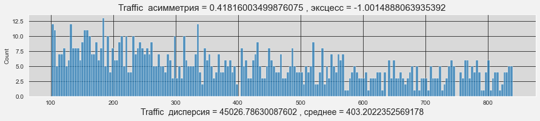

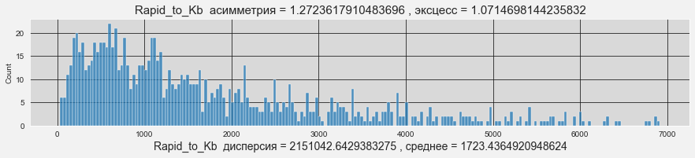

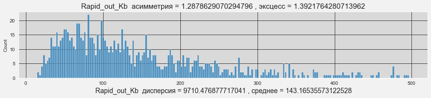

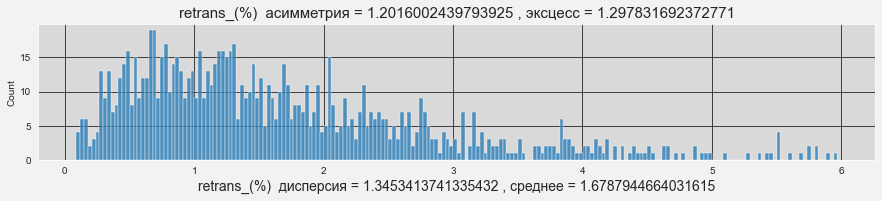

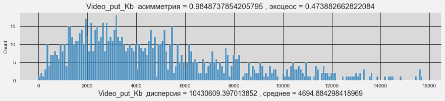

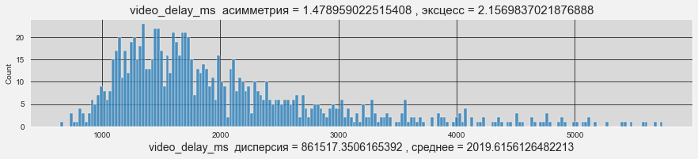

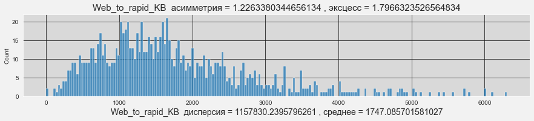

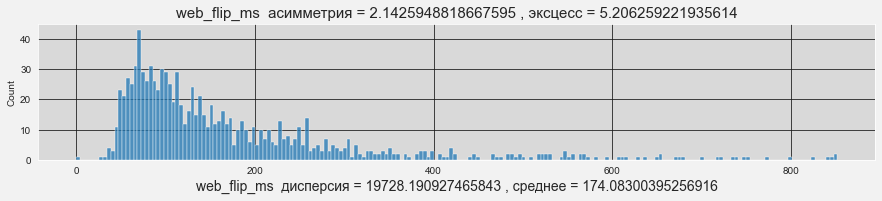

```python
# numeric_features - лист, состоящий из числовых столбцов =  taking only the numeric columns from the dataframe

numeric_features=[x for x in direct.columns if direct[x].dtype!="object"]
for i in direct[numeric_features[:-1]].columns:
    plt.figure(figsize=(15,2.5))
    plt.title(i+'  '  +"асимметрия"+' = '+str(skew(direct[i]))      +' , '+ "эксцесс"+' = '+ str(kurtosis(direct[i])),fontsize=15  )
    plt.xlabel(i+'  ' +"дисперсия"+' = '+str((direct[i].std())**2) +' , '+ "среднее"+' = '+ str(direct[i].mean()) ,fontsize=14    )
    sns.histplot(direct[i], bins = 200)
    sns.set_style('darkgrid',
              {'axes.facecolor': '0.85',
               'grid.color': '0.1',
               'figure.facecolor': '0.95'})
plt.show()
```

### 5.5 График по логарифмам технических показателей для выявления возможных аномалий

```python
# датафрейм логарифмов технических показателей
log_distr = base.groupby(list(base.columns[2:-2]))[['user_id']].count().reset_index().apply(np.log)
log_distr.head(2)
```

|  | Traffic | Rapid_to_Kb | Rapid_out_Kb | retrans_(%) | Video_put_Kb | video_delay_ms | Web_to_rapid_KB | web_flip_ms | user_id |
| --- | --- | --- | --- | --- | --- | --- | --- | --- | --- |
| 0 | 4.616063 | 5.348535 | 4.616703 | 1.091923 | 8.539866 | 7.805882 | 7.756011 | 4.564348 | 0.0 |
| 1 | 4.619102 | 5.177730 | 4.696655 | 0.667829 | 5.825912 | 7.717796 | 5.745596 | 6.276643 | 0.0 |

```python
log_distr =  log_distr[~log_distr.isin([np.nan, np.inf, -np.inf]).any(1)]
```

```python
# !!!!! сработало !!!!!
len(log_distr)
```

```
1011
```

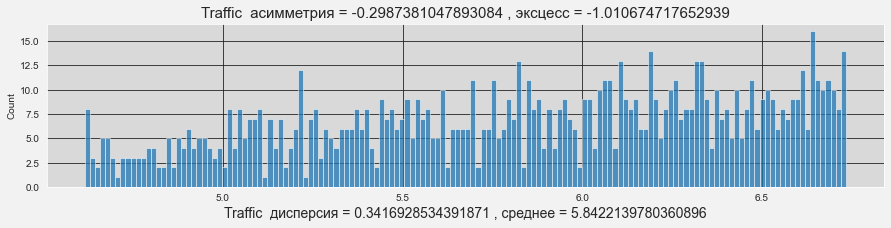

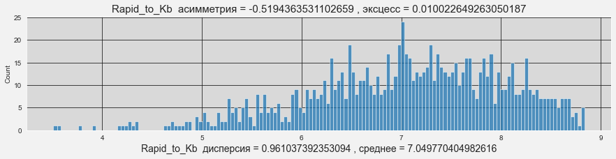

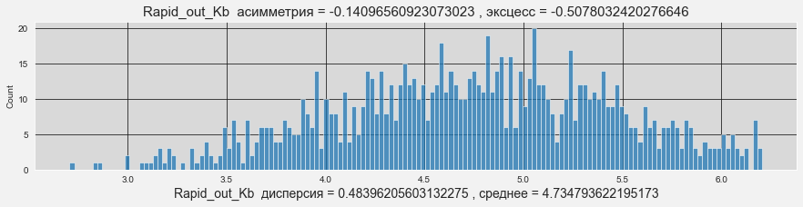

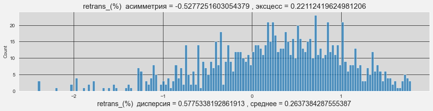

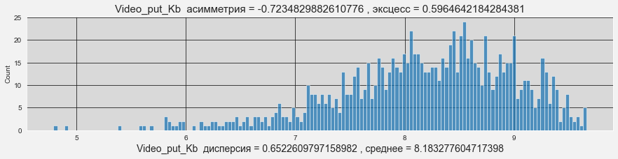

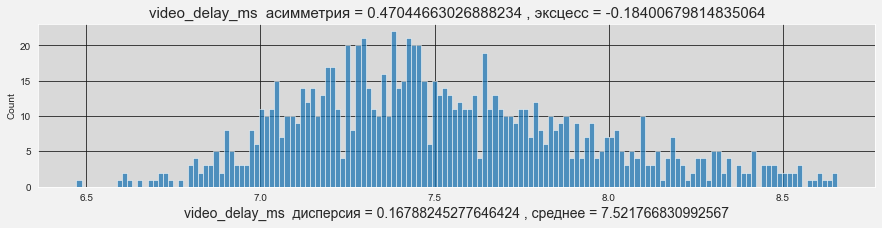

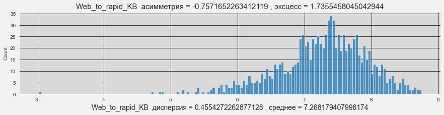

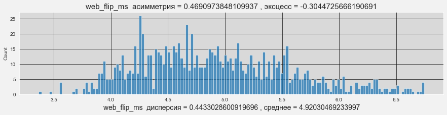

```python
numeric_featuresln=[x for x in log_distr.columns if log_distr[x].dtype!="object"]
for i in log_distr[numeric_featuresln[:-1]].columns:
    plt.figure(figsize=(15,3))
    plt.title(i+'  '  +"асимметрия"+' = '+str(skew(log_distr[i]))      +' , '+ "эксцесс"+' = '+ str(kurtosis(log_distr[i])),fontsize=15  )
    plt.xlabel(i+'  ' +"дисперсия"+' = '+str((log_distr[i].std())**2) +' , '+ "среднее"+' = '+ str(log_distr[i].mean()),fontsize=14     )
    sns.set_style('darkgrid',
              {'axes.facecolor': '0.85',
               'grid.color': '0.1',
               'figure.facecolor': '0.95'})
    sns.histplot(log_distr[i], bins = 150)
plt.show()
```

### 5.6 Распределение технических характеристик по оценкам Q1 (scatterplot)

```python
print(lulu) # список столбцов
```

```
['Traffic', 'Rapid_to_Kb', 'Rapid_out_Kb', 'retrans_(%)', 'Video_put_Kb', 'video_delay_ms', 'Web_to_rapid_KB', 'web_flip_ms']
```

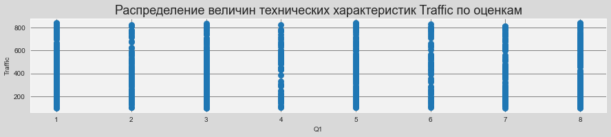

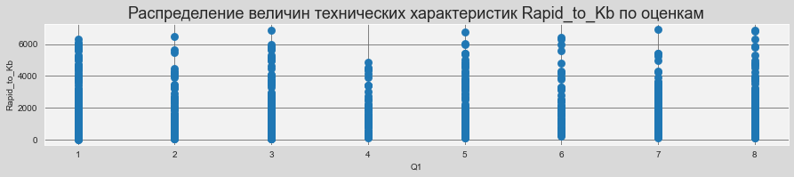

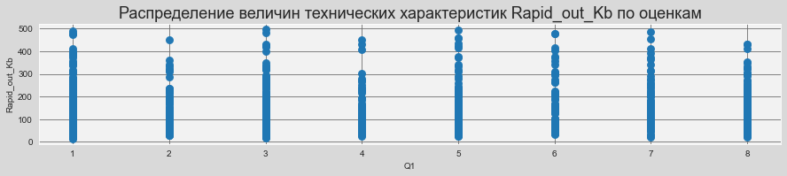

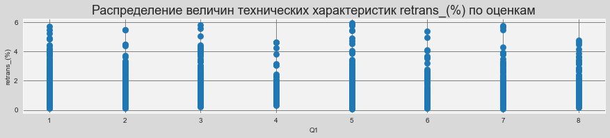

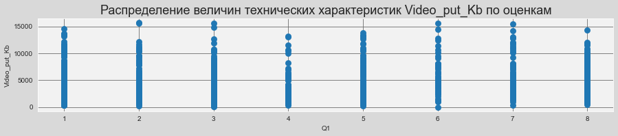

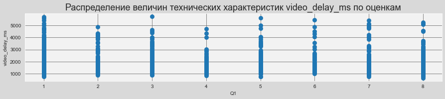

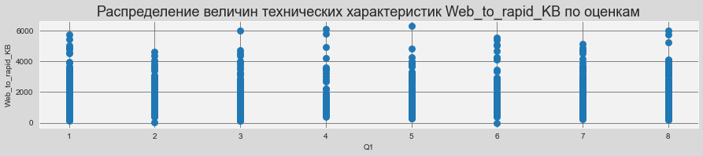

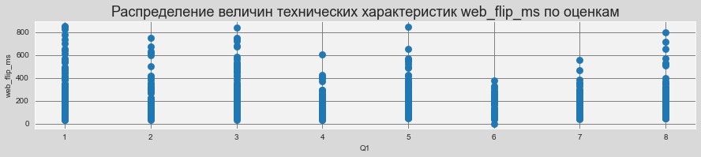

```python
for i in lulu:
    sns.set_style('darkgrid',
              {'axes.facecolor': '0.95',
               'grid.color': '0.4',
               'figure.facecolor': '0.85'})
    plt.figure(figsize=(15,2.5))
    sns.scatterplot(x="Q1", y=i, data=base,linewidth=0, alpha = 0.99, s=80)
    plt.title("Распределение величин технических характеристик " +str(i) +" по оценкам",fontsize=18)
plt.show()
```

### 6. Разведочный анализ

### 6.1 Общее распределение абонентов по субъективной оценке качества связи (Q1) по десятибальной шкале

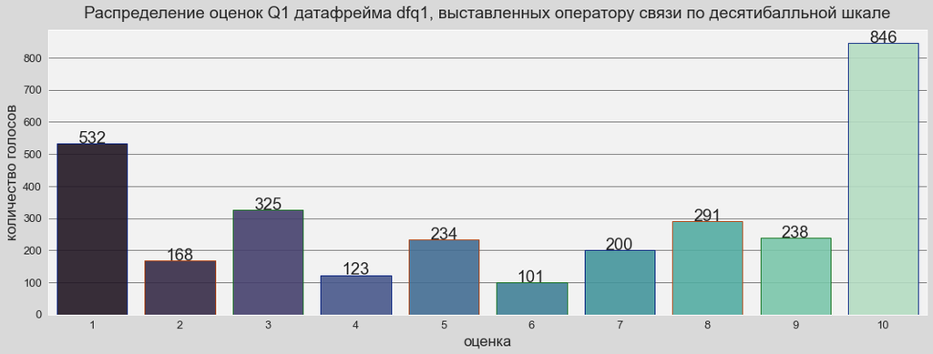

```python
countplt, ax = plt.subplots(figsize = (18,6))
ax =sns.countplot(x = 'Q1', data=dfq1, linewidth=1, alpha=0.9, palette="mako", edgecolor=sns.color_palette("dark", 3))

plt.title("Распределение оценок Q1 датафрейма dfq1, выставленных оператору связи по десятибалльной шкале", fontsize=19,y=1.02)
plt.tick_params(labelsize=13) # ШРИФТ
plt.ylabel('количество голосов',fontsize=17)
plt.xlabel('оценка',fontsize=17)
for rect in ax.patches:
    ax.text (rect.get_x() + rect.get_width()  / 2,rect.get_height()+ 0.75,
             rect.get_height(),horizontalalignment='center', fontsize = 19)
sns.set_style('darkgrid',
              {'axes.facecolor': '0.8',
               'grid.color': '0.7',
               'figure.facecolor': '0.95'})
plt.show()
```

#### Хорошо видны выпадающие из общих оценок две составляющие: 10 и 1, то есть, - или великолепно, или ужасно. В этом прослеживается СУБЪЕКТИВНОСТЬ оценок, что требуется учитывать.

#### 6.2 Распределение оценнок абонентов по десятибальной шкале среди NaN Q2

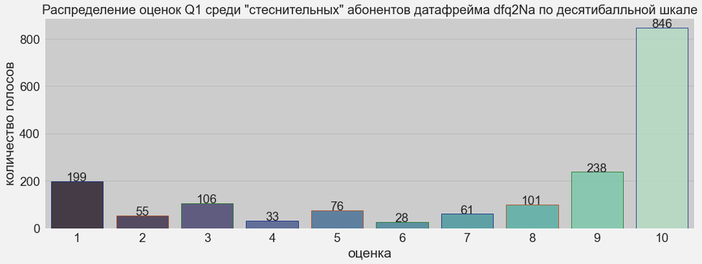

```python
fig, ax = plt.subplots(figsize=(18,6))
sns.set_theme(style="darkgrid")
sns.countplot(x='Q1', data=dfq2Na, linewidth=1, alpha=0.8, palette="mako", edgecolor=sns.color_palette("dark", 3) )#"mako""PRGn"
plt.title('Распределение оценок Q1 среди "стеснительных" абонентов датафрейма dfq2Na по десятибалльной шкале', fontsize=20) # ШРИФТ
plt.tick_params(labelsize=19)

for rect in ax.patches:
    ax.text (rect.get_x() + rect.get_width()  / 2,rect.get_height()+ 0.75,
             rect.get_height(),horizontalalignment='center', fontsize = 19)

plt.ylabel('количество голосов',fontsize=21)
plt.xlabel('оценка',fontsize=21)
sns.set_style('darkgrid',
              {'axes.facecolor': '0.8',
               'grid.color': '0.3',
               'figure.facecolor': '0.95'})
plt.show()
```

#### Данный массив сохраняет максимальное количество "десяток" и "девяток", но демонстрирует уменьшение остальных, особенно между 1 и 9. "Стеснительные" скорее готовы выставить 1 (ужас), чем обосновать позицию конкретными претензиями.

### 6.3 Распределение претензий по категориям

```python
# список номеров, присвоенных претензиям
dfq2['Q2'].unique()
```

```
array([4, 3, 2, 5, 1, 7, 6])
```

```python
# для наглядности: создать словарь di, где ключи - номера, а значения - наименования претензий
di = {1: '1 недозвоны, обрывы при звонках',
      2: '2 время ожидания гудков при звонке',
      3: '3 плохое качество связи в зданиях',
      4: '4 медленный мобильный интернет',
      5: '5 медленная загрузка видео',
      6: '6 затрудняюсь ответить',
      7: '7 свой вариант'}
di
```

```
{1: '1 недозвоны, обрывы при звонках',
 2: '2 время ожидания гудков при звонке',
 3: '3 плохое качество связи в зданиях',
 4: '4 медленный мобильный интернет',
 5: '5 медленная загрузка видео',
 6: '6 затрудняюсь ответить',
 7: '7 свой вариант'}
```

```python
# создать список li всех номеров претензий из столбца Q2
li = list(dfq2['Q2'])
```

```python
# создать список lis претензий, в котором названия соответствуют номерам
lis = []
for i in li:
    for key, value in di.items():
        if key == i:              # по совпадающему ключу отправление в lis название претензии
            lis.append(value)
lis[:3] # посмотреть
```

```
['4 медленный мобильный интернет',
 '4 медленный мобильный интернет',
 '3 плохое качество связи в зданиях']
```

```python
# добавить столбец 'Q2_title' с названиями претензий
dfq2['Q2_title'] = list(lis) # создание столбца из списка то же размерности что и фрейм
dfq2.head(1)
```

|  | user_id | Q1 | Traffic | Rapid_to_Kb | Rapid_out_Kb | retrans_(%) | Video_put_Kb | video_delay_ms | Web_to_rapid_KB | web_flip_ms | Q2 | rank | Q2_title |
| --- | --- | --- | --- | --- | --- | --- | --- | --- | --- | --- | --- | --- | --- |
| 0 | 2 | 5 | 861.96324 | 3023.54 | 411.18 | 1.27 | 667.47 | 2080 | 255.36 | 425 | 4 | 1 | 4 медленный мобильный интернет |

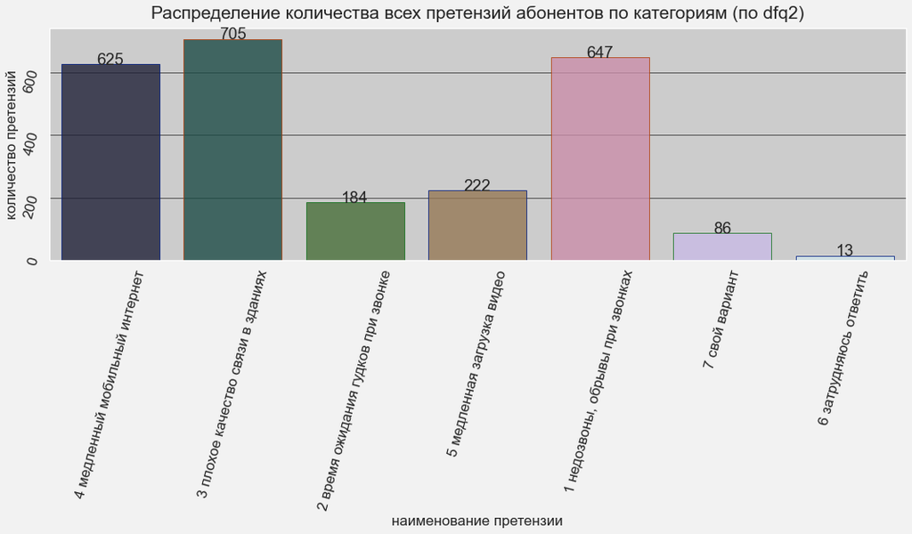

```python
countplt, ax = plt.subplots(figsize=(18,5))
plt.tick_params(labelsize=15, rotation=75)
sns.set_theme(style="darkgrid")

sns.countplot(x='Q2_title', data=dfq2, linewidth=1, alpha=0.8, palette="cubehelix", edgecolor=sns.color_palette("dark", 3) )#"mako""PRGn"
plt.title("Распределение количества всех претензий абонентов по категориям (по dfq2)", fontsize=21,y=1.02)
plt.tick_params(labelsize=17)
plt.ylabel('количество претензий',fontsize=17)
plt.xlabel('наименование претензии',fontsize=17)
for rect in ax.patches:
    ax.text (rect.get_x() + rect.get_width()  / 2,rect.get_height()+ 0.75,
             rect.get_height(),horizontalalignment='center', fontsize = 19)


sns.set_style('darkgrid',
              {'axes.facecolor': '0.8',
               'grid.color': '0.5',
               'figure.facecolor': '0.95'})
plt.show()
```

#### Хорошо обозначены 2 вида основных претензий: а) телефонии ( плохое качество связи в зданиях и недозвоны, обрывы при звонках) и в) - медленный мобильный интернет.

### 6.4 Влияние количества обозначенных претензий на среднюю общую оценку оператора

```python
# df3 - промежуточный фрейм, где все претензии, маркированные по номерам, находятся ещё в списках
df3.head(4)
```

|  | user_id | Q1 | Q2 | Traffic | Rapid_to_Kb | Rapid_out_Kb | retrans_(%) | Video_put_Kb | video_delay_ms | Web_to_rapid_Kb | web_flip_ms |
| --- | --- | --- | --- | --- | --- | --- | --- | --- | --- | --- | --- |
| 1 | 2 | 5 | [4] | 861.96324 | 3023.54 | 411.18 | 1.27 | 667.47 | 2080 | 255.36 | 425 |
| 2 | 3 | 1 | [4] | 261.11860 | 790.96 | 34.20 | 1.79 | 1079.60 | 6367 | 535.85 | 485 |
| 3 | 4 | 8 | [3] | 179.18564 | 2590.97 | 325.88 | 0.80 | 7053.81 | 3218 | 1221.02 | 51 |
| 4 | 5 | 2 | [2, 3, 4] | 351.99208 | 731.61 | 223.54 | 1.15 | 4550.38 | 1767 | 2336.56 | 68 |

```python
# количество элементов (претензий) в каждой ячейке столбца Q2 позволяют сформировать столбец on_fingers
df3['on_fingers'] = df3.Q2.str.len() # просто длина списка
df3.head(4)
```

|  | user_id | Q1 | Q2 | Traffic | Rapid_to_Kb | Rapid_out_Kb | retrans_(%) | Video_put_Kb | video_delay_ms | Web_to_rapid_Kb | web_flip_ms | on_fingers |
| --- | --- | --- | --- | --- | --- | --- | --- | --- | --- | --- | --- | --- |
| 1 | 2 | 5 | [4] | 861.96324 | 3023.54 | 411.18 | 1.27 | 667.47 | 2080 | 255.36 | 425 | 1 |
| 2 | 3 | 1 | [4] | 261.11860 | 790.96 | 34.20 | 1.79 | 1079.60 | 6367 | 535.85 | 485 | 1 |
| 3 | 4 | 8 | [3] | 179.18564 | 2590.97 | 325.88 | 0.80 | 7053.81 | 3218 | 1221.02 | 51 | 1 |
| 4 | 5 | 2 | [2, 3, 4] | 351.99208 | 731.61 | 223.54 | 1.15 | 4550.38 | 1767 | 2336.56 | 68 | 3 |

```python
# средняя оценка Q1 по группам, сформированним исходя из количества претензий, существующих одновременно у абонента
df3g = df3.groupby('on_fingers')['Q1'].mean().reset_index()
df3g
```

|  | on_fingers | Q1 |
| --- | --- | --- |
| 0 | 1 | 4.325321 |
| 1 | 2 | 4.319088 |
| 2 | 3 | 3.478448 |
| 3 | 4 | 2.746667 |
| 4 | 5 | 2.161290 |
| 5 | 6 | 1.000000 |

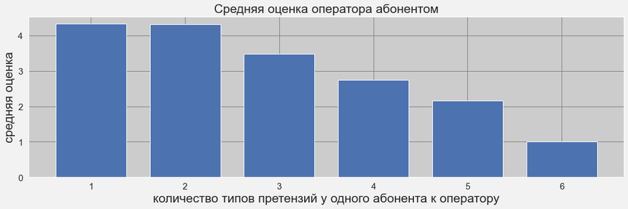

```python
fig, ax = plt.subplots(figsize=(18,5))
plt.bar(df3g['on_fingers'], df3g['Q1'],width=0.75)
plt.title("Средняя оценка оператора абонентом",fontsize=21)
plt.ylabel('средняя оценка',fontsize=21)
plt.xlabel('количество типов претензий у одного абонента к оператору',fontsize=21)
plt.tick_params(labelsize=15) # ШРИФТ
```

#### Умножения претезий стоит избегать, что ярко подтвердится в дальнейшем.

### 6.5 Как абоненты оценивают оператра исходя из конкретной претензии

```python
co = dfq2.groupby('Q2_title')['Q1'].mean().reset_index()
co
```

|  | Q2_title | Q1 |
| --- | --- | --- |
| 0 | 1 недозвоны, обрывы при звонках | 3.687790 |
| 1 | 2 время ожидания гудков при звонке | 3.603261 |
| 2 | 3 плохое качество связи в зданиях | 3.890780 |
| 3 | 4 медленный мобильный интернет | 3.756800 |
| 4 | 5 медленная загрузка видео | 3.747748 |
| 5 | 6 затрудняюсь ответить | 6.076923 |
| 6 | 7 свой вариант | 2.918605 |

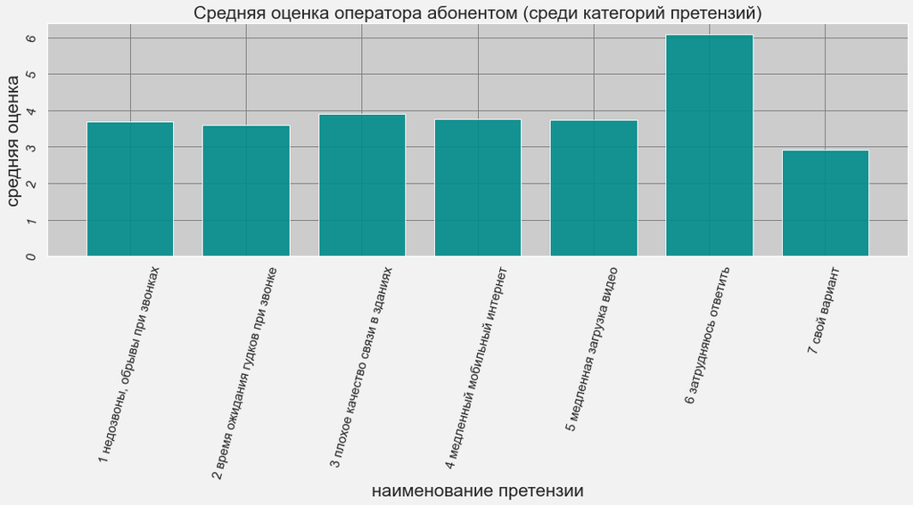

```python
fig, ax = plt.subplots(figsize=(18,5))
plt.bar(co['Q2_title'], co['Q1'],width=0.75, color='DarkCyan', alpha=0.9)

plt.title("Средняя оценка оператора абонентом (среди категорий претензий)",fontsize=21)
plt.ylabel('средняя оценка',fontsize=21)
plt.xlabel('наименование претензии',fontsize=21)

plt.tick_params(labelsize=15, rotation=75) # ШРИФТ
```

Если у абонента неопределённые томления (пункт 6), на величине оценки это сказывается менее, чем при томлениях определённых. А вот величина оценки при разных, но конкретных претензиях практичести одинаковая, хотя наименьшая оценка выставляется если есть своя, выстраданная, неповторимая претензия (7).

### 7. Cтатистический анализ. Бутстреп.

##### Тестирование методом БУТСТРЕП зависимости выставленной оценки от индивидуальных технических показателей (по датафрейму dfq1 с оценками от 10 до 1)

#### 7.1 Демонстрация. На технической характеристике Video_put_Kb две пары оценённых показателей

```python
names = list(dfq1.columns)[4:] # все технические характеристики
print(names)
```

```
['Rapid_to_Kb', 'Rapid_out_Kb', 'retrans_(%)', 'Video_put_Kb', 'video_delay_ms', 'Web_to_rapid_Kb', 'web_flip_ms']
```

```python
# группировка фрейма по оценкам по first в user_id (они в единственном экземпляре - хоть first, хоть last)
a = dfq1.groupby(['Q1', 'user_id'])['Video_put_Kb'].first().reset_index()
print(len(a))
a.head(1)
```

```
3058
```

|  | Q1 | user_id | Video_put_Kb |
| --- | --- | --- | --- |
| 0 | 1 | 3 | 1079.6 |

```python
# перевод вертикальной (3058) структуры фрейма в горизонтальную, где столбцы - массивы технических характеристик

dd = a[a['Q1']==1] # начальный фрейм, к нему будут последующие присоединения
for j in range(2,11): # начало цикла с двойки, окончание на десятке
    ku = a[a['Q1']==j].reset_index() # текущий фрейм в цикле
    ku = ku.drop(['Q1'], axis = 1) # убрать ненужный
    ku = ku.drop(['user_id'], axis = 1) # убрать ненужный
    ku = ku.rename(columns={'Video_put_Kb': j}) # проименовать столбцы, полученные в цикле по оценкам (от 2 до 10)
    dd = dd.merge(ku, how='outer', left_index=True, right_index=True ) # слияние с dd
dd.head(1)
```

|  | Q1 | user_id | Video_put_Kb | index_x | 2 | index_y | 3 | index_x | 4 | index_y | 5 | index_x | 6 | index_y | 7 | index_x | 8 | index_y | 9 | index | 10 |
| --- | --- | --- | --- | --- | --- | --- | --- | --- | --- | --- | --- | --- | --- | --- | --- | --- | --- | --- | --- | --- | --- |
| 0 | 1.0 | 3.0 | 1079.6 | 532.0 | 4550.38 | 700.0 | 4553.01 | 1025.0 | 1136.43 | 1148.0 | 1859.15 | 1382.0 | 5234.92 | 1483.0 | 1583.27 | 1683.0 | 7053.81 | 1974.0 | 16753.96 | 2212 | 9844.23 |

```python
dd = dd.rename(columns={'Video_put_Kb': 1}) # переименовать столбец исходного фрейма в 1
dd.head(1)
```

|  | Q1 | user_id | 1 | index_x | 2 | index_y | 3 | index_x | 4 | index_y | 5 | index_x | 6 | index_y | 7 | index_x | 8 | index_y | 9 | index | 10 |
| --- | --- | --- | --- | --- | --- | --- | --- | --- | --- | --- | --- | --- | --- | --- | --- | --- | --- | --- | --- | --- | --- |
| 0 | 1.0 | 3.0 | 1079.6 | 532.0 | 4550.38 | 700.0 | 4553.01 | 1025.0 | 1136.43 | 1148.0 | 1859.15 | 1382.0 | 5234.92 | 1483.0 | 1583.27 | 1683.0 | 7053.81 | 1974.0 | 16753.96 | 2212 | 9844.23 |

```python
ddd = dd[[1,2,3,4,5,6,7,8,9,10]] # искомый фрейм для дальнейшей демонстрации. (Полный столбец без нанов только у 10)
ddd.head()
```

|  | 1 | 2 | 3 | 4 | 5 | 6 | 7 | 8 | 9 | 10 |
| --- | --- | --- | --- | --- | --- | --- | --- | --- | --- | --- |
| 0 | 1079.60 | 4550.38 | 4553.01 | 1136.43 | 1859.15 | 5234.92 | 1583.27 | 7053.81 | 16753.96 | 9844.23 |
| 1 | 6802.42 | 1699.64 | 1317.76 | 10669.25 | 667.47 | 6519.35 | 1560.77 | 2438.20 | 13224.96 | 2490.93 |
| 2 | 8747.53 | 632.07 | 2621.14 | 17208.51 | 894.42 | 4872.09 | 631.31 | 9774.81 | 1564.11 | 7215.26 |
| 3 | 2483.79 | 11702.86 | 675.88 | 3891.66 | 7256.13 | 11622.84 | 2863.04 | 4327.61 | 10355.96 | 5943.66 |
| 4 | 1367.23 | 6017.85 | 8878.63 | 4000.41 | 29670.67 | 4642.87 | 20236.29 | 2724.09 | 6437.73 | 1913.33 |

```python
d = ddd.copy() # копия
len(d)
```

```
846
```

##### 7.1.1 Бутстреп в 3000 выборок по 846 показателям в выборке по столбцам оценок 10 и 1

#### У характеристики 'Video_put_Kb' чем больше показатель - тем лучше. Поэтому предполагается, что оценке "10" должны соответствовать более высокие значения, чем оценке "1". Исходя из этого строятся нулевая и альтернативная гипотезы.

```python
ar10 =  np.array(d[10]) # создать массив из колонки с оценкой 10
ar1 = np.array(d[1])# создать массив из колонки с оценкой 1
ar1 = ar1[~np.isnan(ar1)] # убрать наны из массива

# анализ проводится по средним значениям в столбцах, где наименования столбцов - выставленные оценки
# отправная точка бутстрепа - средние значения по столбцу 1 и по столбцу 10 датафрейма d
# логика характеристики 'Video_put_Kb' предполагают что значения в столбце 10 должны быть больше, чем в столбце 1, поэтому:
  # a) нулевая гипотеза требует наличие  p_value >= 0.05 и пересечение доверительных интервалов бутстрепных средних по столбцам
  # b) альтернативная - p_value < 0.05 и непересекающихся доверительных интервалов по средним бутстрепным выборкам

m_old1 = ar1.mean() # среднее значение исходного столбца с наименованием 1 датафрейма d; old - как будто начального, МЕНЬШЕГО
m_new10 = ar10.mean() # среднее значение исходного столбца с наименованием 10 датафрейма d, new - как будто вторичного, БОЛЬШЕГО
delta101 = m_new10 - m_old1 # разность средних значений исходных столбцов датафрейма d, должна быть положительной по условиям

# Цикл бутстрепа
li1=[] # список сбора средних рандомных значений характеристики 'Video_put_Kb' по оценке 1
li10=[] # список сбора средних рандомных значений характеристики 'Video_put_Kb' по оценке 10
differences101 = [] # список сбора разностей средних рандомных выборок по 10 И 1
rasmer = 3000 # количество рандомных выборок
for i in range(1, rasmer+1):
    s1 = random.choices(ar1, k = 846) # случайная выборка по исходной 1 размерностью k
    s10 = random.choices(ar10, k = 846) # случайная выборка по исходной 10 размерностью k
    m1 = np.mean(s1) # среднее значение случайной выборки
    m10 = np.mean(s10) #  среднее значение случайной выборки
    diff101 = m10 - m1 # разность средних по каждой паре рандомных выборок, нужно для расчёта "приведённого к нулю" p_value

    li1.append(m1) # список средних по рандомным выборкам
    li10.append(m10) # список средних по рандомным выборкам
    differences101.append(diff101) # список с разностями средних по каждой паре рандомных выборок

print(delta101, "- первичная разность средних по столбцам оценок, ориентир для p_value на графике")
print(' ')

ar_differences101 = np.array(differences101) # преобразовать список разностей средних в массив
average_ar_differences101 = ar_differences101.mean() # среднее значение в списке разностей для расчёта p_value
print(average_ar_differences101, "-средняя разность значений в списке разностей значений")
print(' ')

ar_differences101_center = ar_differences101 - average_ar_differences101 # отцентрованные к нулю значения для расчета p_value
p_value = sum(ar_differences101_center >= delta101)/rasmer
print("p_value =",p_value,".(Если p_value меньше 0,05 - нулевая отвергается, если больше 0,05 - нулевая подтверждается)")
print(' ')

dovint1 = np.percentile(li1,[2.5,97.5]) # доверительный 95% интервал распределения средних рандомных показателей в столбце 1
dovint10 = np.percentile(li10,[2.5,97.5])# доверительный 95% интервал распределения средних рандомных показателей в столбце 10
print(dovint1, "доверительный интервал рандомных средних показателей в столбце оценок 1")
print(dovint10, "доверительный интервал рандомных средних показателей в столбце оценок 10")
```

```
1340.978606534064 - первичная разность средних по столбцам оценок, ориентир для p_value на графике

1337.719144795114 -средняя разность значений в списке разностей значений

p_value = 0.0 .(Если p_value меньше 0,05 - нулевая отвергается, если больше 0,05 - нулевая подтверждается)

[4570.97095892 5238.48977423] доверительный интервал рандомных средних показателей в столбце оценок 1
[5890.08339628 6567.28572222] доверительный интервал рандомных средних показателей в столбце оценок 10
```

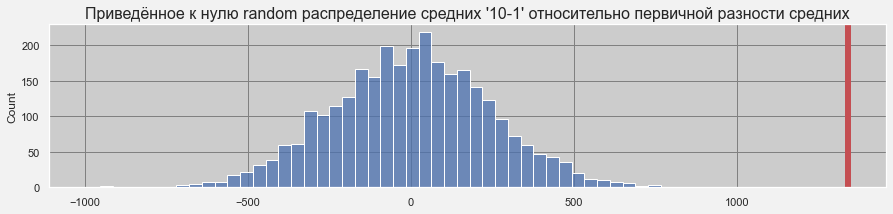

```python
# положение распределения относительно первичной разности средних по столбцам оценок
plt.figure(figsize=(15,3))
plt.title("Приведённое к нулю random распределение средних '10-1' относительно первичной разности средних",fontsize=16)
sns.histplot(ar_differences101_center, bins = 50)
plt.axvline(delta101, linewidth = 6,c='r' )
```

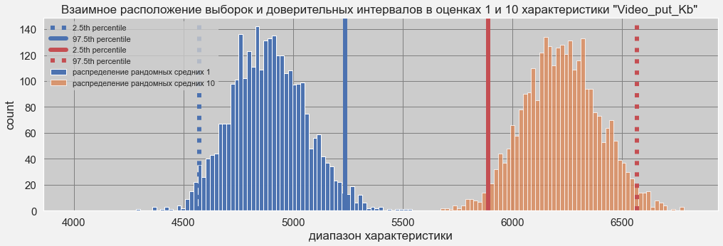

```python
plt.figure(figsize=(17,5))
bins = np.linspace(4000, 6800, 150)

plt.hist(li1, bins, alpha = 0.99, label='распределение рандомных средних 1')
plt.axvline(x=np.percentile(li1,[2.5]), ymin=0, ymax=1,label='2.5th percentile',c='b', linewidth = 6,linestyle = ':')
plt.axvline(x=np.percentile(li1,[97.5]), ymin=0, ymax=1,label='97.5th percentile',c='b', linewidth = 6,linestyle = '-')


plt.hist(li10, bins, alpha = 0.75, label='распределение рандомных средних 10')
plt.axvline(x=np.percentile(li10,[2.5]), ymin=0, ymax=1,label='2.5th percentile',c='r', linewidth = 6,linestyle = '-')
plt.axvline(x=np.percentile(li10,[97.5]), ymin=0, ymax=1,label='97.5th percentile',c='r', linewidth = 6,linestyle = ':')


plt.legend(loc='upper left')

plt.ylabel('count',fontsize=17)
plt.xlabel('диапазон характеристики',fontsize=17)
plt.tick_params(labelsize=15) # ШРИФТ

plt.title('Взаимное расположение выборок и доверительных интервалов в оценках 1 и 10 характеристики "Video_put_Kb" ',fontsize=17)

plt.show()
```